# Reproducible Research Project 1

### Loading and preprocessing the data

#### 1. Loading the needed libraries

```r
library(ggplot2)
library(Hmisc)
```

#### 2. Process/transform the data

```r
activityData <- read.csv('activity.csv')
```

### What is mean total number of steps taken per day?

#### 1. Calculate the total number of steps taken per day

```r
dailySteps <- tapply(activityData$steps, activityData$date, sum)
```

#### 2. Make a histogram of the total number of steps taken each day

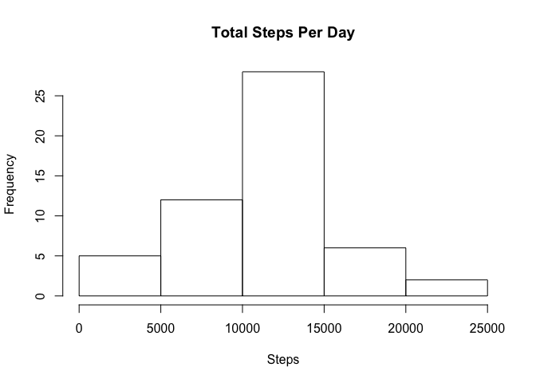

```r
hist(dailySteps, xlab = "Steps", main = "Total Steps Per Day")
```

```r
Mean <- round(mean(dailySteps, na.rm = TRUE), 2)
Median <- (median(dailySteps, na.rm=TRUE))
```

### What is the average daily activity pattern?

#### 1. Make a time series plot (i.e. type = “l”) of the 5-minute interval (x-axis) and the average number of steps taken, averaged across all days (y-axis)

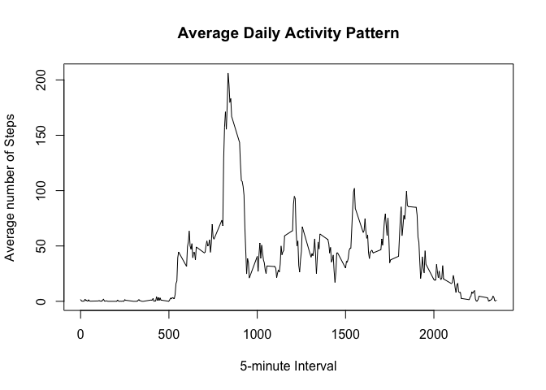

```r
stepsInterval <- tapply(activityData$steps, activityData$interval, mean, na.rm = TRUE)
plot(as.numeric(names(stepsInterval)),
     stepsInterval,
     xlab = "5-minute Interval", ylab = "Average number of Steps",
     main = "Average Daily Activity Pattern", type = "l")
```

#### 2. Which 5-minute interval, on average across all the days in the dataset, contains the maximum number of steps?

```r
maxInterval <- names(sort(stepsInterval, decreasing = TRUE)[1])
maxSteps <- round(max(stepsInterval), 2)
```

The 5-minute interval that contains the maximum number of steps is 835 with 206.17 steps.

### Imputing missing values

#### 1. Calculate and report the total number of missing values in the dataset (i.e. the total number of rows with NAs)

```r
missingValues <- sum(is.na(activityData$steps))
```

The total number of missing values in this data set is 2304.

#### 2. Devise a strategy for filling in all of the missing values in the dataset.

Replace missing data in data set with the mean steps across the days.

#### 3. Create a new dataset that is equal to the original dataset but with the missing data filled in.

```r
actDataImp <- activityData
actDataImp$steps <- impute(activityData$steps, fun=mean)
```

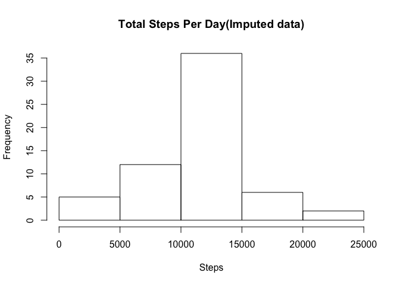

```r
dailyStepsImp <- tapply(actDataImp$steps, actDataImp$date, sum)
hist(dailyStepsImp, xlab = "Steps", main = "Total Steps Per Day(Imputed data)")
```

```r
MeanImp <- round(mean(dailyStepsImp), 2)
MedianImp <- (median(dailyStepsImp))
```

### Are there differences in activity patterns between weekdays and weekends?

#### 1. Create a new factor variable in the dataset with two levels – “weekday” and “weekend” indicating whether a given date is a weekday or weekend day.

```r
actDataImp$date <-  ifelse(as.POSIXlt(actDataImp$date)$wday %in% c(0,6), 'weekend', 'weekday')
```

#### 2. Make a panel plot containing a time series plot (i.e. type = “l”) of the 5-minute interval (x-axis) and the average number of steps taken, averaged across all weekday days or weekend days (y-axis).

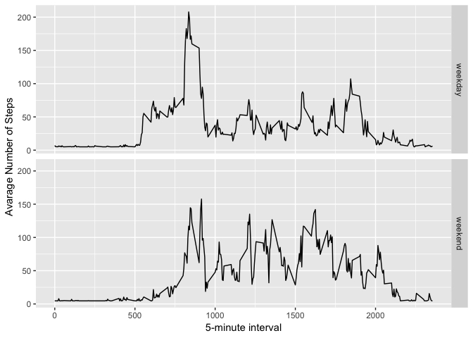

```r
avgActDataImp <- aggregate(steps ~ interval + date, data=actDataImp, mean)
ggplot(avgActDataImp, aes(interval, steps)) +
    geom_line() +
    facet_grid(date ~ .) +
    xlab("5-minute interval") +
    ylab("Avarage Number of Steps")
```